# Sampling distribution of the sample mean

02/27/14

### Announcements

- I will hand back exam 1 **after** class.
- Exam solutions are now on Blackboard. Please double check **why** you lost points **before** you ask questions!
- We're behind most the other sections, we've got lots of difficult material to cover!

### Learning Objectives for Chapter 14.1

- Understand how to specify the **sampling distribution of the sample mean** (that is, how to find it's mean, variance and **shape**).
- Understand how sampling distributions are created. The lecture notes uses the K-Packs example to demonstrate this idea. [Think about exam scores.](http://glimmer.rstudio.com/cpsievert/CLT/)
- [This video](http://www.youtube.com/embed/jvoxEYmQHNM) nicely demonstrates the behavior of the sampling distribution when we increase sample size.

### Why does shape matter?

- In Chapter 12, you found probabilities such as \( P(X < 5) \).
- This process assumes the **shape** of the **population** distribution is normal!
- We now relax this assumption – the **shape** can be either **normal** or **non-normal**.
- For example, if the shape of the population distribution is non-normal, you **cannot** find \( P(X < 5) \)!

### Population distribution

- From now on, the notation \( X \sim N(\mu, \sigma^2) \) tells us 3 things about a **population**:
  - **Shape**: Normal distribution
  - **Mean**: \( \mu \)
  - **Standard Deviation**: \( \sigma \)
- If I write \( X \sim (\mu, \sigma^2) \), the **shape** is **not** normal.

### The sample mean is a random variable!

- In practice, \( \mu \) is unknown; so we use a **sample mean** to **estimate** it.
- Since samples are **random**, the sample mean can be thought of as a **random variable** \( \bar{X} \) (before taking the sample).
- All random variables have a **distribution**. The **distribution** of \( \bar{X} \) is called the **sampling distribution of the sample mean**.
- Given the **shape**, **mean**, and **variance** of the population; it is fairly easy to specify the **distribution** of \( \bar{X} \).

### The sample mean is a random variable!

- Assuming we have a **simple random sample**, \( \bar{X} \) will be **unbiased**.
- That is, the **mean** of \( \bar{X} \), denoted as \( (\mu_{\bar{X}}) \), is equal to…

  the population mean \( (\mu) \).
- The **variance** of \( \bar{X} \), denoted as \( \sigma^2_{\bar{X}} \), is equal to…

  \( \sigma^2/n \)
- \( n \) is the sample size. What is the value of \( \sigma^2_{\bar{X}} \) when \( n=1 \)?
- The **shape** of \( \bar{X} \) depends on (possibly) two things: (1) the shape of \( X \) (2) the sample size \( n \).

### Shape of the sampling distribution of the sample mean

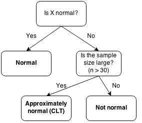